# Bayesian Assignment 2

Gavin Connolly

25/02/2022

## Introduction

The dataset which you will analyse in this assignment involves data of 200 house prices (in units of 1, 000 euro) in a particular suburb of Co. Dublin. The floor area of each house (in square metres) is also given

```r
dublinproperty <- read.csv("property.csv")

str(dublinproperty) # Look at summary of data
```

```
## 'data.frame':    200 obs. of  3 variables:
##  $ X    : int  1 2 3 4 5 6 7 8 9 10 ...
##  $ area : int  117 112 153 138 104 140 29 143 165 176 ...
##  $ price: num  1046 864 998 968 732 ...
```

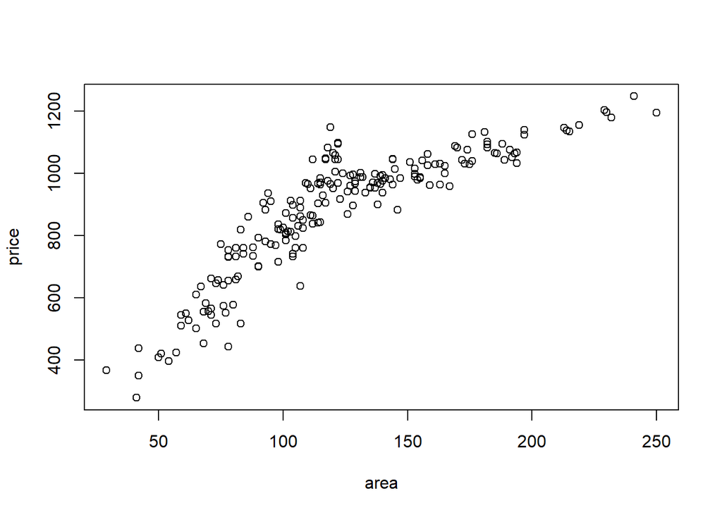

```r
area <- dublinproperty$area
price <- dublinproperty$price
plot(area, price) # look at plot of the data to check for patterns
```

```r
# looks as if a regression line through data would cross y-axis at price of roughly 300
# may be a good centre for our prior on the alpha/intercept term of our model
```

The objective here is to develop a Bayesian linear regression model and implement it in Stan.

- Describe clearly your model including the priors that you have chosen. Generally, you should choose priors that are quite vague and uninformative.
- Produce a Stan program to fit this model. Present and interpret the results from this model.
- Plot the data together with 90% posterior credible intervals for the posterior mean line as well as 90% credible interval for the posterior predicted prices.
- Are you happy with the model fit? If not, explain why and suggest changes that could be made to the model to rectify this.

For my priors, I have chosen the following for each of the parameters in the model:

- $\alpha$, the intercept term for our linear regression model for the mean $\mu$: Uniform prior, taking values on the interval 0 to 500.

  We have no real information on what the prior for the intercept should be other than it should be greater than 0. I have then chosen an upper bound of 500 as €500,000 seems like a decent upper bound for the minimum price for a house (or in this case a house with 0 area).
- $\beta$, the slope term for our linear regression model for the mean $\mu$: Normal prior, w/ mean 0 & standard deviation of 10.

  I have chosen this prior as it is centred around 0, which assumes there is no linear relationship between the 2 variables; area & price. I have then chosen a standard deviation of 10 as it allows the parameter to take a relatively wide range of values & provide flexibility for the posterior estimates.
- $\sigma$, the standard deviation for our model of the price: Uniform prior on the interval (0, 200).

  This prior assumes σ takes values between 0 & 200 with equal probability. This is a relatively non-informative prior to account for the uncertainty in the parameter. We have then calculated a value μ, the mean of the distribution of house prices for a given area using the regression equation: $\mu_i = \alpha + \beta \cdot x_i$

The house price is then computed using a normal distribution with parameters $\mu_i$ & $\sigma$.

```r
d <- dublinproperty

dat <- list(N = NROW(dublinproperty), area = area, price = price)

writeLines(readLines("LinRegModel.stan"))
```

```
##
## data {
##   int<lower=1> N;
##   vector[N] price;
##   vector[N] area;
## }
## parameters {
##   real alpha;
##   real beta;
##   real<lower=0,upper=200> sigma; // uniform prior on sigma
## }
## model {
##   vector[N] mu = alpha + beta * area;  //
##   target += normal_lpdf(price | mu, sigma);
##   target += uniform_lpdf(alpha | 0, 500); // prior centred around 0 with high standard deviation
##   target += normal_lpdf(beta | 0, 10); // 0 centred prior assumes no relation
## }
```

```r
fit_1 <- stan(file="LinRegModel.stan", data=dat, iter=5000)

monitor(fit_1) # rhat = 1 for each variable, chain converged
```

```
## Inference for the input samples (4 chains: each with iter = 5000; warmup = 0):
##
##            Q5     Q50     Q95    Mean   SD  Rhat Bulk_ESS Tail_ESS
## alpha   357.5   391.4   426.3   391.9 21.1     1     3991     4608
## beta      3.7     4.0     4.2     4.0  0.2     1     3910     4322
## sigma    92.1    99.8   108.7   100.1  5.0     1     5231     4885
## lp__  -1212.2 -1209.6 -1208.5 -1209.8  1.2     1     3596     4902
##
## For each parameter, Bulk_ESS and Tail_ESS are crude measures of
## effective sample size for bulk and tail quantities respectively (an ESS > 100
## per chain is considered good), and Rhat is the potential scale reduction
## factor on rank normalized split chains (at convergence, Rhat <= 1.05).
```

[output not shown]

[output not shown]

## Question 2

Let’s now modify the posterior model by instead modelling the relationship between house price and log(area).

- Implement this model using Stan. Interpret the output from this model.
- Similar to Q1, provide a 90% credible interval for the mean and also a 90% posterior prediction intervals. Plot data overlaying the posterior mean credible interval and also the posterior predictive interval.
- Provide a brief commentary on your analysis.

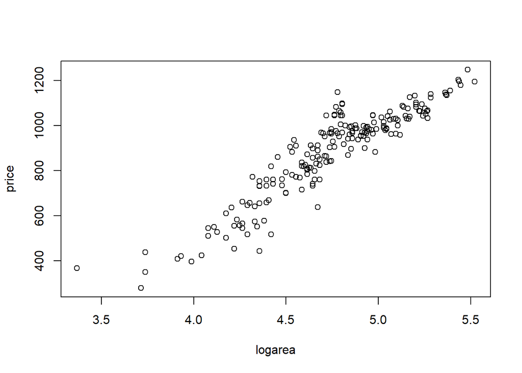

```r
logarea <- log(area)
d2 <- as.data.frame(matrix(data = c(logarea, price), nrow = 200, ncol = 2, byrow = FALSE))
dat2 <- list(N = NROW(dublinproperty), logarea = logarea, price = dublinproperty$price)

plot(logarea, price)
```

```r
# harder to see where regression line would cross y-axis in this case
# prior with high variance centred around -1000 seems appropriate
```

```r
writeLines(readLines("LogLinRegModel.stan"))
```

```
##
## data {
##   int<lower=1> N;
##   vector[N] price;
##   vector[N] logarea;
## }
## parameters {
##   real alpha;
##   real beta;
##   real<lower=0,upper=200> sigma;
## }
## model {
##   vector[N] mu = alpha + beta * logarea;
##   target += normal_lpdf(price | mu, sigma);
##   target += normal_lpdf(alpha | 0, 500); // value of 1 corresponds to price of 0
##   target += normal_lpdf(beta | 0, 200); // assume no relation (centred on 0)
## }
```

```r
fit_2 <- stan(file="LogLinRegModel.stan", data=dat2, iter=5000)

monitor(fit_2) #rhat = 1 for all variables, meaning chain has converged
```

```
## Inference for the input samples (4 chains: each with iter = 5000; warmup = 0):
##
##            Q5     Q50     Q95    Mean   SD  Rhat Bulk_ESS Tail_ESS
## alpha -1524.3 -1408.5 -1295.5 -1409.3 69.2     1     2927     3385
## beta    458.8   482.7   506.9   482.8 14.6     1     2923     3372
## sigma    71.7    77.7    84.7    77.9  4.0     1     3454     3606
## lp__  -1172.9 -1170.2 -1169.2 -1170.5  1.3     1     3028     3835
##
## For each parameter, Bulk_ESS and Tail_ESS are crude measures of
## effective sample size for bulk and tail quantities respectively (an ESS > 100
## per chain is considered good), and Rhat is the potential scale reduction
## factor on rank normalized split chains (at convergence, Rhat <= 1.05).
```

```r
post <- as.data.frame(fit_2)
cor(cbind(post$alpha,post$beta)) # Correlation between alpha and beta reveals strong correlation between each.
```

```
##           [,1]      [,2]
## [1,]  1.000000 -0.996874
## [2,] -0.996874  1.000000
```

It appears from the graph that this new linear model fits the data much better than our initial model, but we can also see that there remains a cluster of outlying datapoints around the 120 $m^2$ mark. Overall, the model seems to be a decent fit for the data, with the majority of the datapoints lying on/around the regression line.

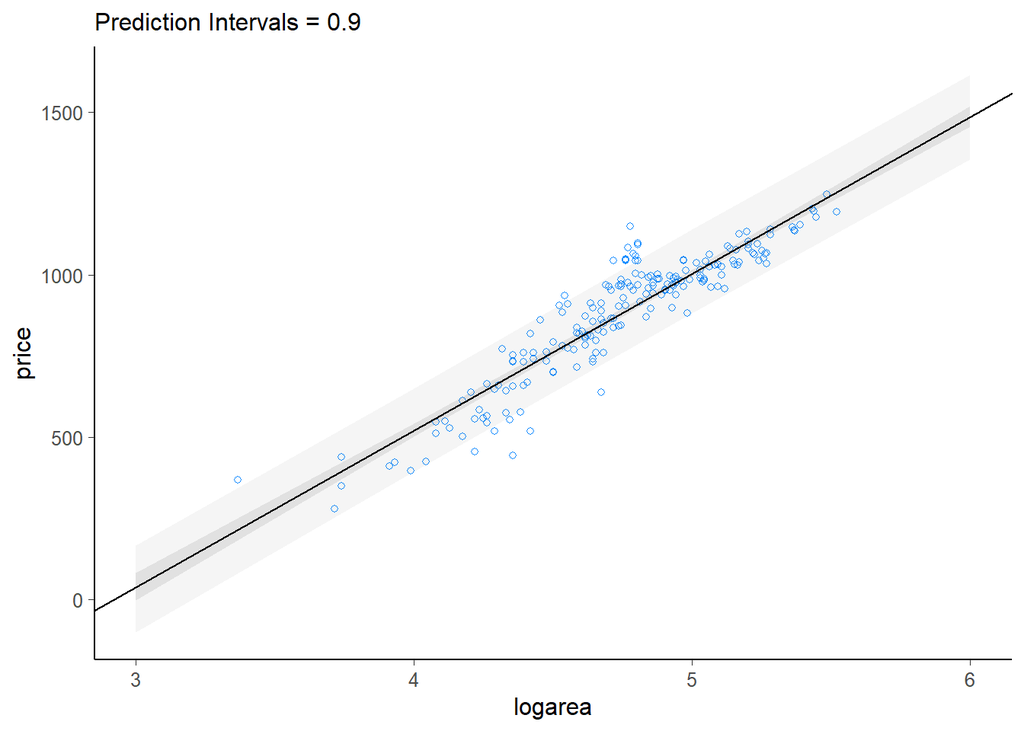

```r
f_mu <- function(x) post$alpha + post$beta * x
area_new <- seq(3, 6) # plot seemed to have data lying on interval (3,6)
mu1 <- sapply(area_new, f_mu)

# calculate 90% credible interval for regression mean
y_hdi = HDInterval::hdi(mu1, credMass=0.9)
hpdi_l = y_hdi[1,]
hpdi_u = y_hdi[2,]

p <- ggplot()
# store plot of regression line as well as 90% credible interval for regression mean
p2 <- p +
  geom_point(data = d2,
             aes(logarea, price), shape = 1, color = 'dodgerblue') +
  geom_ribbon(aes(area_new, ymin = hpdi_l, ymax = hpdi_u),
              alpha = .1) +
  geom_abline(data = post,
              aes(intercept = mean(alpha), slope = mean(beta))) +
  labs(subtitle="HPDI Interval = 0.9")

y_pi <- sapply(area_new,
               function(x) rnorm(NROW(post), post$alpha + post$beta * x, post$sigma)
)

# calculate 90% credible intervals for prediction intervals
y_phdi = HDInterval::hdi(y_pi, credMass=0.9)
pi_l = y_phdi[1,]
pi_u = y_phdi[2,]

# plot prediction intervals along with regression line & credible interval for linear mean
p2 + geom_ribbon(mapping = aes(area_new, ymin=pi_l, ymax=pi_u), alpha = 0.05) +
  labs(subtitle = 'Prediction Intervals = 0.9')
```

## Question 3

Following from Q2, use the Bayesian model to predict a house price for a house with a floor area of 75$m^2$, providing also a credible interval for this prediction. Repeat the analysis for a house with a floor area of 175$m^2$.

```r
# apply f_mu function to log of 75
mu_75 <- sapply(log(75), f_mu)
# calculate highest posterior density interval for the prediction
y_hdi_75 = HDInterval::hdi(mu_75, credMass=0.9)
# calculate mean of the predictions as point estimate of our prediction
mean(mu_75)
```

```
## [1] 675.2142
```

```r
# show prediction interval
pi_75 = y_hdi_75[,1]
pi_75
```

```
##    lower    upper
## 661.6245 688.4786
```

```r
# repeat same analysis for area of 175 m^2
mu_175 <- sapply(log(175), f_mu)
y_hdi_175 = HDInterval::hdi(mu_175, credMass=0.9)

pi_175 = y_hdi_175[,1]
mean(mu_175)
```

```
## [1] 1084.294
```

```r
pi_175
```

```
##    lower    upper
## 1071.091 1098.188
```